# Task-3 EDA Retail

Shashwat Patel

05/02/2021

# **Attaching the packages**

```r
library(tidyverse)
library(GGally)
library(gridExtra)
```

# **Read the data**

```r
data<-read.csv("SampleSuperstore.csv")
```

```r
head(data)
```

```
##        Ship.Mode   Segment       Country            City      State Postal.Code
## 1   Second Class  Consumer United States       Henderson   Kentucky       42420
## 2   Second Class  Consumer United States       Henderson   Kentucky       42420
## 3   Second Class Corporate United States     Los Angeles California       90036
## 4 Standard Class  Consumer United States Fort Lauderdale    Florida       33311
## 5 Standard Class  Consumer United States Fort Lauderdale    Florida       33311
## 6 Standard Class  Consumer United States     Los Angeles California       90032
##   Region        Category Sub.Category    Sales Quantity Discount    Profit
## 1  South       Furniture    Bookcases 261.9600        2     0.00   41.9136
## 2  South       Furniture       Chairs 731.9400        3     0.00  219.5820
## 3   West Office Supplies       Labels  14.6200        2     0.00    6.8714
## 4  South       Furniture       Tables 957.5775        5     0.45 -383.0310
## 5  South Office Supplies      Storage  22.3680        2     0.20    2.5164
## 6   West       Furniture  Furnishings  48.8600        7     0.00   14.1694
```

# **Basic summary of the data**

```r
str(data)
```

```
## 'data.frame':    9994 obs. of  13 variables:
##  $ Ship.Mode   : Factor w/ 4 levels "First Class",..: 3 3 3 4 4 4 4 4 4 4 ...
##  $ Segment     : Factor w/ 3 levels "Consumer","Corporate",..: 1 1 2 1 1 1 1 1 1 1 ...
##  $ Country     : Factor w/ 1 level "United States": 1 1 1 1 1 1 1 1 1 1 ...
##  $ City        : Factor w/ 531 levels "Aberdeen","Abilene",..: 195 195 267 154 154 267 267 267 267 267 ...
##  $ State       : Factor w/ 49 levels "Alabama","Arizona",..: 16 16 4 9 9 4 4 4 4 4 ...
##  $ Postal.Code : int  42420 42420 90036 33311 33311 90032 90032 90032 90032 90032 ...
##  $ Region      : Factor w/ 4 levels "Central","East",..: 3 3 4 3 3 4 4 4 4 4 ...
##  $ Category    : Factor w/ 3 levels "Furniture","Office Supplies",..: 1 1 2 1 2 1 2 3 2 2 ...
##  $ Sub.Category: Factor w/ 17 levels "Accessories",..: 5 6 11 17 15 10 3 14 4 2 ...
##  $ Sales       : num  262 731.9 14.6 957.6 22.4 ...
##  $ Quantity    : int  2 3 2 5 2 7 4 6 3 5 ...
##  $ Discount    : num  0 0 0 0.45 0.2 0 0 0.2 0.2 0 ...
##  $ Profit      : num  41.91 219.58 6.87 -383.03 2.52 ...
```

```r
summary(data)
```

```
##           Ship.Mode           Segment              Country
##  First Class   :1538   Consumer   :5191   United States:9994
##  Same Day      : 543   Corporate  :3020
##  Second Class  :1945   Home Office:1783
##  Standard Class:5968
##
##
##
##             City               State       Postal.Code        Region
##  New York City: 915   California  :2001   Min.   : 1040   Central:2323
##  Los Angeles  : 747   New York    :1128   1st Qu.:23223   East   :2848
##  Philadelphia : 537   Texas       : 985   Median :56431   South  :1620
##  San Francisco: 510   Pennsylvania: 587   Mean   :55190   West   :3203
##  Seattle      : 428   Washington  : 506   3rd Qu.:90008
##  Houston      : 377   Illinois    : 492   Max.   :99301
##  (Other)      :6480   (Other)     :4295
##             Category         Sub.Category      Sales              Quantity
##  Furniture      :2121   Binders    :1523   Min.   :    0.444   Min.   : 1.00
##  Office Supplies:6026   Paper      :1370   1st Qu.:   17.280   1st Qu.: 2.00
##  Technology     :1847   Furnishings: 957   Median :   54.490   Median : 3.00
##                         Phones     : 889   Mean   :  229.858   Mean   : 3.79
##                         Storage    : 846   3rd Qu.:  209.940   3rd Qu.: 5.00
##                         Art        : 796   Max.   :22638.480   Max.   :14.00
##                         (Other)    :3613
##     Discount          Profit
##  Min.   :0.0000   Min.   :-6599.978
##  1st Qu.:0.0000   1st Qu.:    1.729
##  Median :0.2000   Median :    8.666
##  Mean   :0.1562   Mean   :   28.657
##  3rd Qu.:0.2000   3rd Qu.:   29.364
##  Max.   :0.8000   Max.   : 8399.976
##
```

# **Exploratory Data Analysis**

- Different colours in the plots denote different regions of the United States.

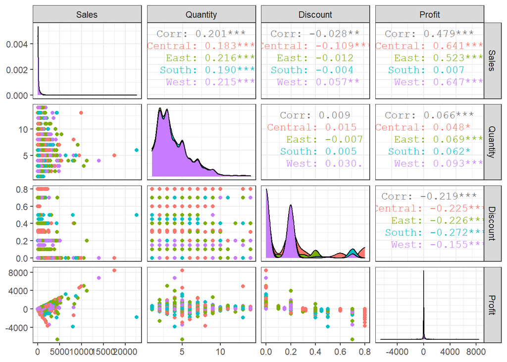

```r
num_data<-data[,10:13]
ggpairs(num_data,aes(colour=data$Region))+theme_bw()
```

- Standard Class seems to remain the preffered mode for shipment and it might be due to its prices being cheap.
- Same day shipment remains the less as all companies don’t offer same day delivery and it is very expensive so people don’t prefer it.
- Majority of shipment is done in the Western region of United States.
- Office supplies are majorly shipped across the United States.

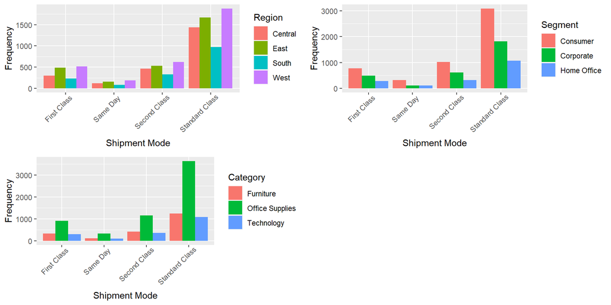

```r
p1<-ggplot(data)+geom_bar(aes(Ship.Mode,fill=Region),position = "dodge")+
  theme(axis.text.x = element_text(angle=45,hjust=0.9))+xlab("Shipment Mode")+
  ylab("Frequency")
p2<-ggplot(data)+geom_bar(aes(Ship.Mode,fill=Segment),position="dodge")+
  theme(axis.text.x = element_text(angle=45,hjust=0.9))+xlab("Shipment Mode")+
  ylab("Frequency")
p3<-ggplot(data)+geom_bar(aes(Ship.Mode,fill=Category),position="dodge")+
  theme(axis.text.x = element_text(angle=45,hjust=0.9))+xlab("Shipment Mode")+
  ylab("Frequency")
grid.arrange(p1,p2,p3,nrow=2)
```

- Office supplies are most in demand in all segments. Furniture and Technological equipments are pretty close with each other on the basis of demand in the market.

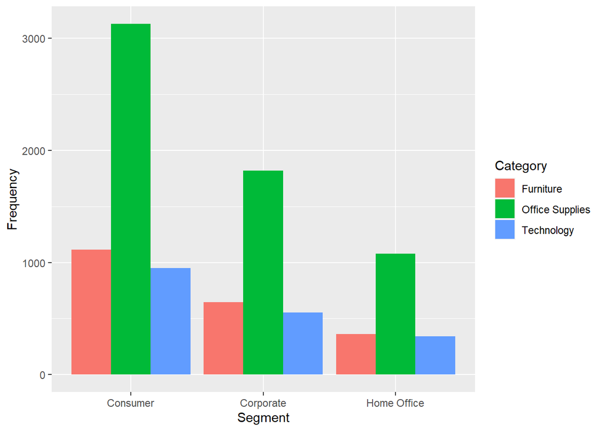

```r
plot1<-ggplot(data)+geom_bar(aes(Segment,fill=Category),position="dodge")+ ylab("Frequency")
plot1
```

- Consumer remains the major buyer of all goods in all regions.
- West and East region are major byuers of good. Southern region has made least purchases.

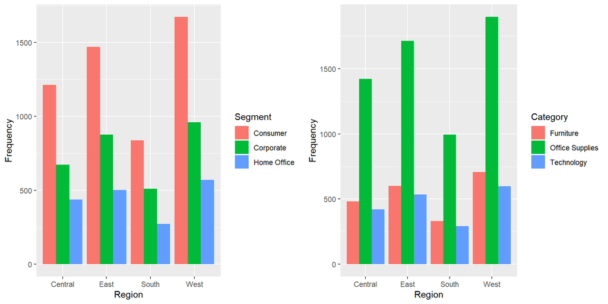

```r
pl1<-ggplot(data)+geom_bar(aes(Region,fill=Segment),position = "dodge")+ ylab("Frequency")
pl2<-ggplot(data)+geom_bar(aes(Region,fill=Category),position="dodge")+ ylab("Frequency")
grid.arrange(pl1,pl2,ncol=2)
```

- Major sales in Eastern and Western region, while Southern region region has least sale.

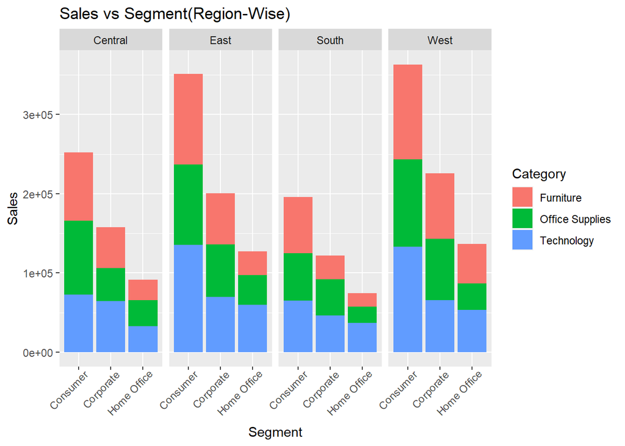

```r
seg_sale_region<-ggplot(data)+geom_col(aes(x=Segment,y=Sales,fill=Category))+facet_grid(.~Region)+
  theme(axis.text.x = element_text(angle=45,hjust=0.9))
seg_sale_region+ggtitle("Sales vs Segment(Region-Wise)")
```

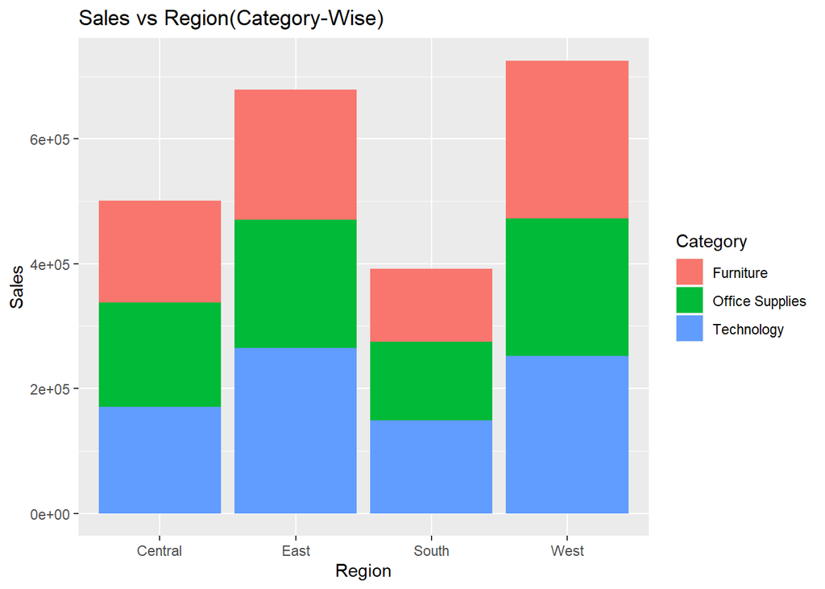

```r
region_sales<-ggplot(data)+geom_col(aes(x=Region,y=Sales,fill=Category))
region_sales+ggtitle("Sales vs Region(Category-Wise)")
```

- There is major profit in sales of Technology. Office supplies is pretty close.
- There seems to be less profit for furniture even though its sale seems to be pretty good.

```r
profit_sum<-data%>%group_by(Category)%>% summarise(Profits=sum(Profit))
profit_sum
```

```
## # A tibble: 3 x 2
##   Category        Profits
##   <fct>             <dbl>
## 1 Furniture        18451.
## 2 Office Supplies 122491.
## 3 Technology      145455.
```

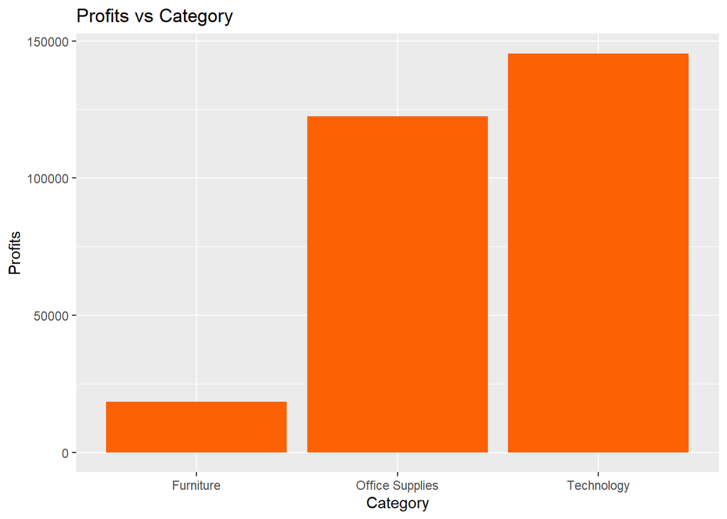

```r
profit_sum%>%ggplot()+geom_col(aes(x=Category,y=Profits),fill="#fc6203")+ggtitle("Profits vs Category")
```

- Most profitable region remains the Western region, which has highest amount of sales.
- Most shocking thing is that, Southern region has least amount of sales, even then its profit is greater than central region.

```r
region_profit<-data%>% group_by(Region)%>% summarise(Profits=sum(Profit))
region_profit
```

```
## # A tibble: 4 x 2
##   Region  Profits
##   <fct>     <dbl>
## 1 Central  39706.
## 2 East     91523.
## 3 South    46749.
## 4 West    108418.
```

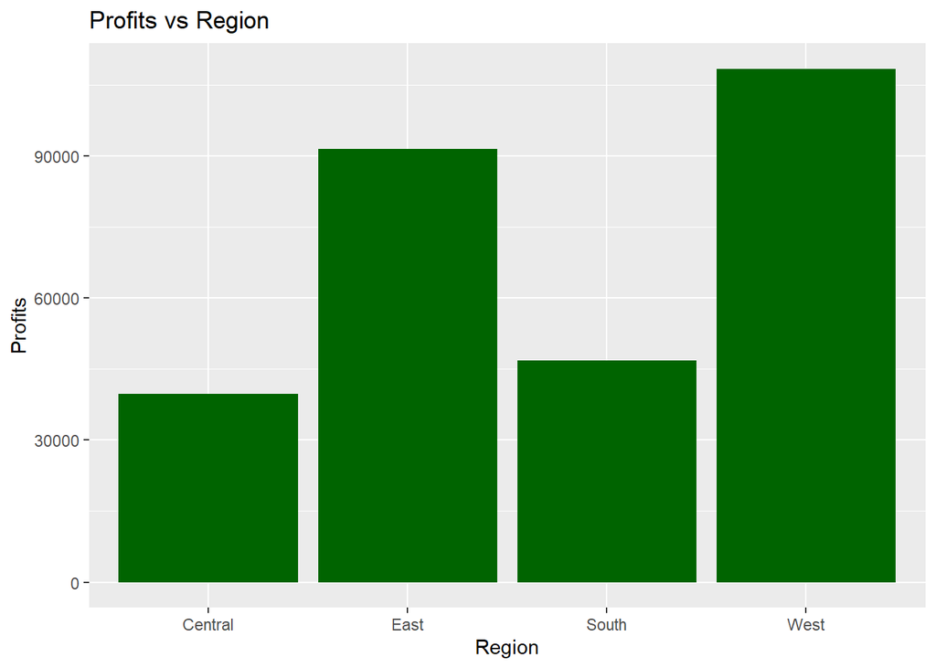

```r
region_profit%>%ggplot()+geom_col(aes(x=Region,y=Profits),fill="darkgreen")+ggtitle("Profits vs Region")
```

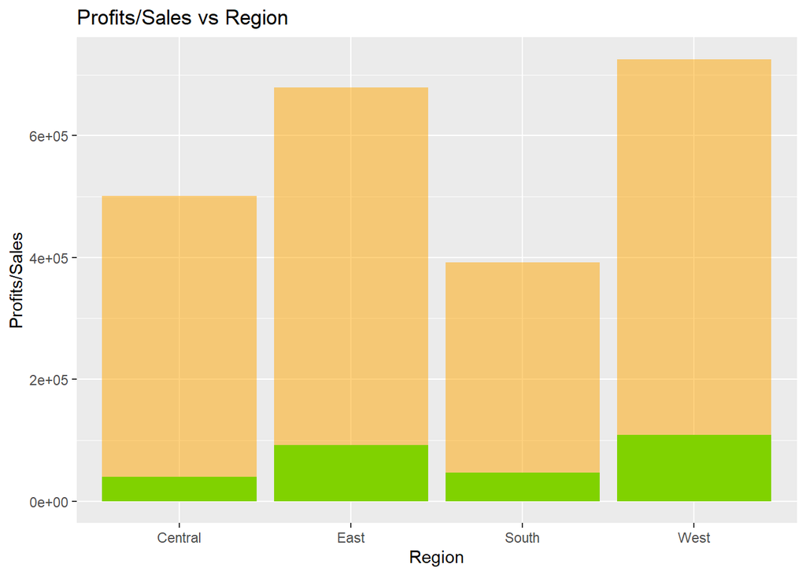

```r
ggplot()+geom_col(data=region_profit,aes(x=Region,y=Profits),fill="green")+geom_col(data=data,aes(x=Region,y=Sales),fill="orange",alpha=0.5)+ggtitle("Profits/Sales vs Region")+ylab("Profits/Sales")
```

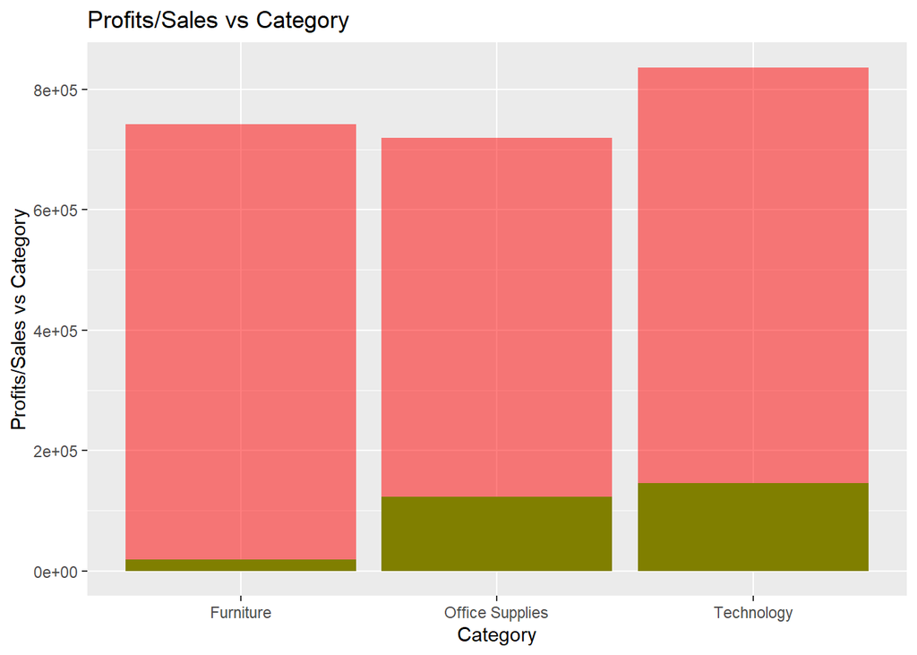

```r
ggplot()+geom_col(data=profit_sum,aes(x=Category,y=Profits),fill="green")+geom_col(data=data,aes(x=Category,y=Sales),fill="red",alpha=0.5)+ylab("Profits/Sales vs Category")+ggtitle("Profits/Sales vs Category")
```

- Different kinds of sub categories under technology, office supplies and furniture.

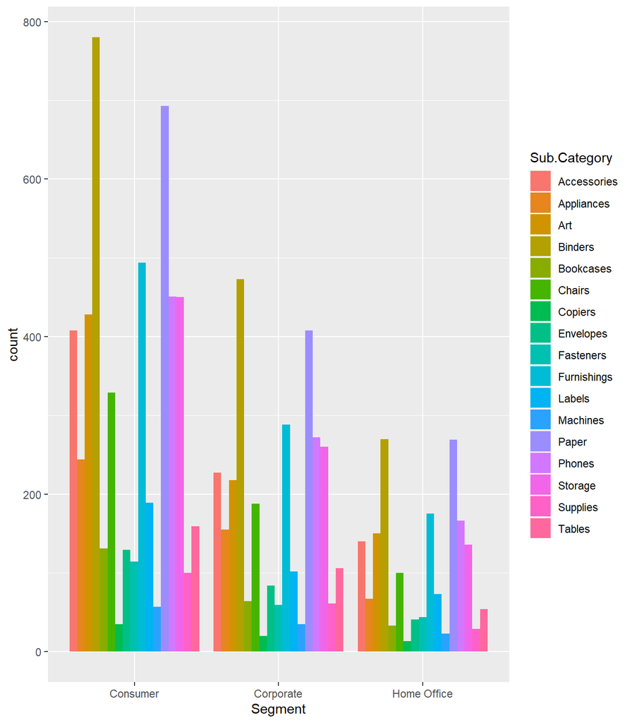

```r
ggplot(data)+geom_bar(aes(x=Segment,fill=Sub.Category),position = "dodge")
```

- Tables has good sales but it has significant amount of negative profit. Samecase with bookcases but to lesser extent.

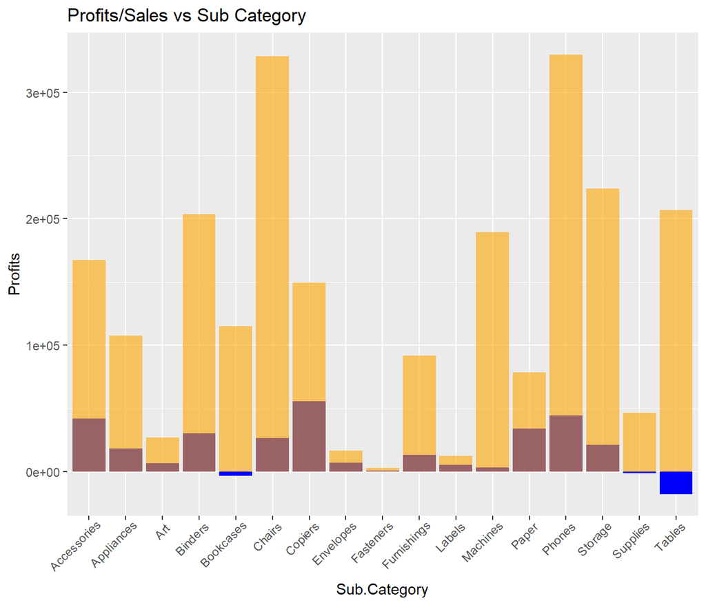

```r
subCategory_profit<-data%>%group_by(Sub.Category)%>%summarise(Profits=sum(Profit),Sale=sum(Sales))
subCategory_profit%>%ggplot()+geom_col(aes(x=Sub.Category,y=Profits),fill="blue")+
  geom_col(aes(x=Sub.Category,y=Sale),fill="orange",alpha=0.6)+
  ggtitle("Profits/Sales vs Sub Category")+theme(axis.text.x = element_text(angle=45,hjust=0.9))
```

```r
salesprofit_city<-data%>%group_by(City)%>%summarise(Sales=sum(Sales),Profit=sum(Profit))
head(salesprofit_city)
```

```
## # A tibble: 6 x 3
##   City          Sales  Profit
##   <fct>         <dbl>   <dbl>
## 1 Aberdeen      25.5     6.63
## 2 Abilene        1.39   -3.76
## 3 Akron       2730.   -187.
## 4 Albuquerque 2220.    634.
## 5 Alexandria  5520.    319.
## 6 Allen        290.    -39.9
```

- New York City has highest amount of sales as well as highest profit.
- None of the cities with least amount of sale is featured in 5 cities with least profit.
- There is peculiar case of **Philadelphia** as well. It is featured in top 5 cities with highest sales but has least amount of profit.

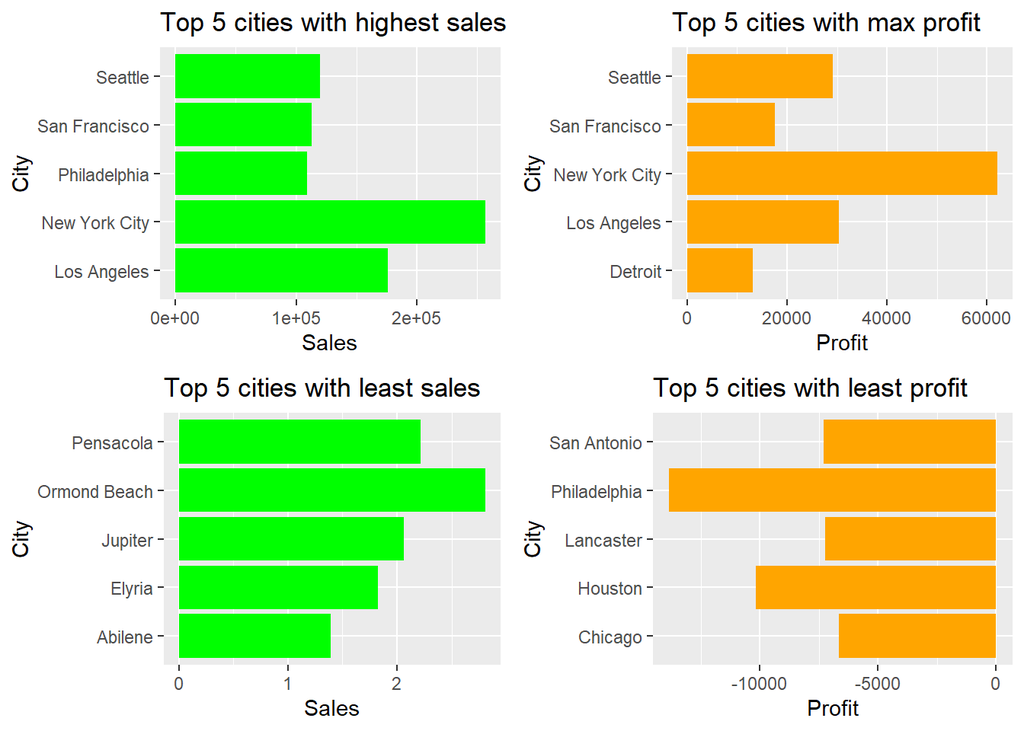

```r
sale1<-salesprofit_city%>%slice_max(Sales,n=5)%>%ggplot()+geom_col(aes(x=City,y=Sales),fill="green")+
  coord_flip()+ggtitle("Top 5 cities with highest sales")
sale2<-salesprofit_city%>%slice_min(Sales,n=5)%>%ggplot()+geom_col(aes(x=City,y=Sales),fill="green")+
  coord_flip()+ggtitle("Top 5 cities with least sales")
profit1<-salesprofit_city%>%slice_max(Profit,n=5)%>%ggplot()+geom_col(aes(x=City,y=Profit),fill="orange")+
  coord_flip()+ggtitle("Top 5 cities with max profit")
profit2<-salesprofit_city%>%slice_min(Profit,n=5)%>%ggplot()+geom_col(aes(x=City,y=Profit),fill="orange")+
  coord_flip()+ggtitle("Top 5 cities with least profit")
grid.arrange(sale1,profit1,sale2,profit2,ncol=2)
```

- Looking at the data, region-wise there seems to be a general trend of decreasing discount leads to increase in profit

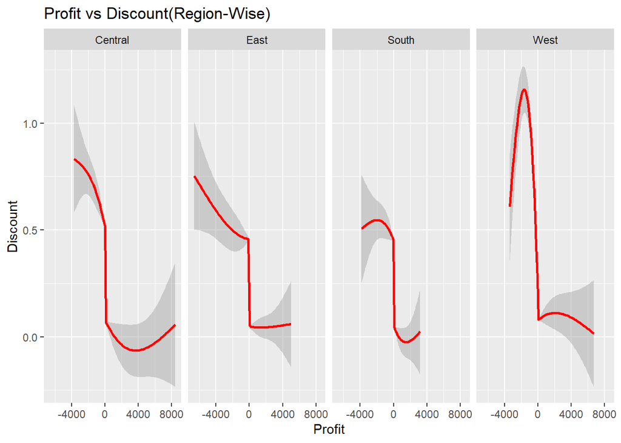

```r
ggplot(data)+geom_smooth(aes(x=Profit,y=Discount),colour="red")+facet_grid(.~Region)+
  ggtitle("Profit vs Discount(Region-Wise)")
```

- There seems to be no relation with amount of discount and Quantity. There might be a weak linaerly increasing relationship between them.

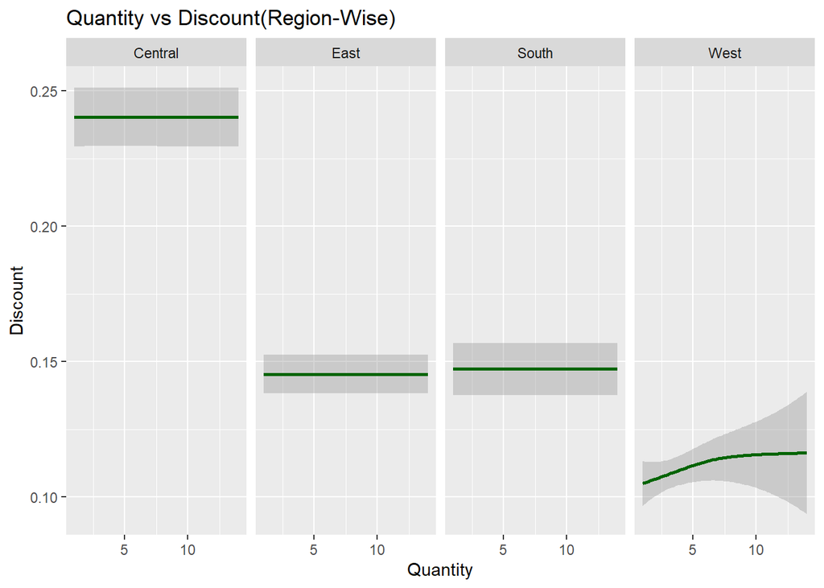

```r
ggplot(data)+geom_smooth(aes(x=Quantity,y=Discount),colour="darkgreen")+facet_grid(.~Region)+
  ggtitle("Quantity vs Discount(Region-Wise)")
```

- There is increase in profit with increase in quantity in general in all the regions. There might be a case of outlier in Central region

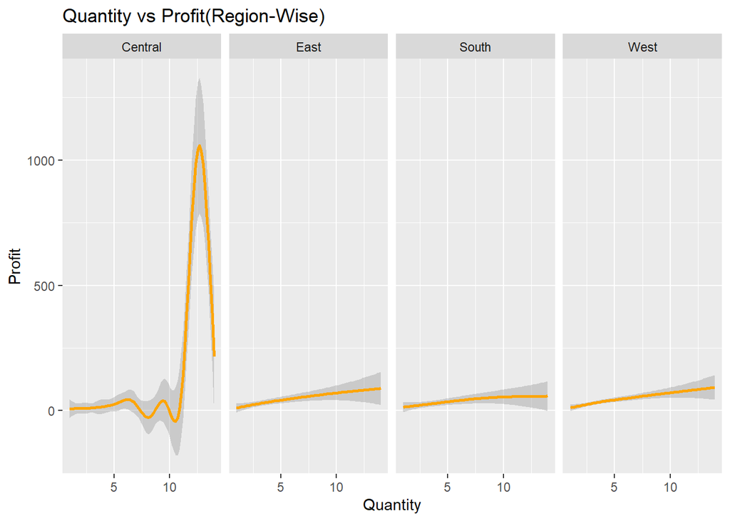

```r
ggplot(data)+geom_smooth(aes(x=Quantity,y=Profit),colour="orange")+facet_grid(.~Region)+
  ggtitle("Quantity vs Profit(Region-Wise)")
```

# **Conclusions**

1.**Standard Class** shipping mode remains the preffered choice. It may be due to its lesser price and everyone can afford it.